# Vignette MetaIntegrator

Winston A. Haynes, Francesco Vallania, Aurelie Tomczak, Timothy E. Sweeney, Erika Bongen, Aditya M. Rao, Purvesh Khatri

2020-02-25

# Contents

## 0.1 Introduction

The MetaIntegrator package comprises several analysis and plot functions to perform integrated multi-cohort analysis of gene expression data (meta-analysis). The advent of the gene expression microarray has allowed for a rapid increase in gene expression studies. Largely due to the MIAME standards for data sharing, many of these studies have been deposited into public repositories such as the NIH Gene Expression Omnibus (GEO) and ArrayExpress. There is now a wealth of publicly available gene expression data available for re-analysis.

An obvious next step to increase statistical power in detecting changes in gene expression associated with some condition is to aggregate data from multiple studies. However, inter-study technical and biological differences prevent us from simply pooling results and summarizing our findings. A random-effects model of meta-analysis circumvents these issues by assuming that the results from each study is drawn from a single distribution, and that such inter-study differences are thus a ‘random effect’. Thus, the MetaIntegrator package will perform a DerSimonian & Laird random-effects meta-analysis for each gene (not probeset) between all target studies between cases and controls; it also performs a Fischers sum-of-logs method on the same data, and requires that a gene is significant by both methods. The resulting p-values are False discovery rate (FDR) corrected to q-values, and will evaluate the hypothesis of whether each gene is differentially expressed between cases and controls across all studies included in the analysis.

The resulting list of genes with significantly different expression between cases and controls can be used for multiple purposes, such as (1) a new diagnostic or prognostic test for the disease of interest, (2) a better understanding of the underlying biology, (3) identification of therapeutic targets, and multiple other applications. Our lab has already used these methods in a wide variety of diseases, including organ transplant reject, lung cancer, neurodegenerative disease, and sepsis ([Khatri et al., J Exp Med 2013](http://www.ncbi.nlm.nih.gov/pmc/articles/PMC3804941/); [Chen et al, Cancer Res 2014](http://cancerres.aacrjournals.org/content/74/10/2892.long); [Li et al., Acta Neur Comm 2014](http://www.actaneurocomms.org/content/2/1/93); Sweeney et al, Sci Trans Med 2015).

The MetaIntegrator Vignette will take the user through the basic steps of the package, including basic multi-cohort analysis, leave-one-out (LOO) analysis (whereby each of the included datasets is left out and multi-cohort analysis is run on the remaining datasets in a round-robin fashion), selection of significant genes, and then analysis of the gene set. The MetaIntegrator package assumes that the user (1) already has their data in hand, and (2) has already decided which datasets to include in the multi-cohort meta-analysis. Our group recommends that some datasets be left out of the analysis, if possible, for independent validation.

**Contact**  
Winston A. Haynes hayneswa@stanford.edu

**Links**

- Package on bitbucket: [`MetaIntegrator`](https://bitbucket.org/khatrilab/metaintegrator_public)

**Installation**

```
install.packages("MetaIntegrator")
```

## 0.2 The Meta-Analysis Algorithm

### 0.2.1 Meta-analysis of gene expression data

The Metaintegrator package can be used to run a meta-analysis on microarray gene expression data as described in [Khatri et al. J Exp Med. 2013](http://www.ncbi.nlm.nih.gov/pmc/articles/PMC3804941/). Briefly, it computes an Hedges’ g effect size for each gene in each dataset defined as:

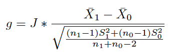

Eq1

where $W_i$ is a weight equal to $1/(V_i+T^2)$, where $V_i$ is the variance of that gene within a given dataset $i$, and $T^{2}$ is the inter-dataset variation (for details see: [Borenstein M et al Introduction to Meta-analysis, Wiley 2009](http://www.wiley.com/WileyCDA/WileyTitle/productCd-EHEP002313.html)). For each gene, the False discovery rate (FDR) is computed and a final set of genes is selected based on FDR thresholding.

### 0.2.2 Computation of a signature score

For a set of signature genes, a signature score can be computed as:

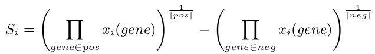

Eq3

## 0.3 Overview Meta-Analysis workflow

**1. Data collection, curation and annotation, select datasets for discovery and validation: *Helper Functions***  
**2. Meta-analysis on discovery datasets: *Meta-Analysis, Filtering, Validation, Visualization, Search, Helper Functions***  
**3. Validation on independent validation datasets: *Visualization, Validation, Helper Functions***

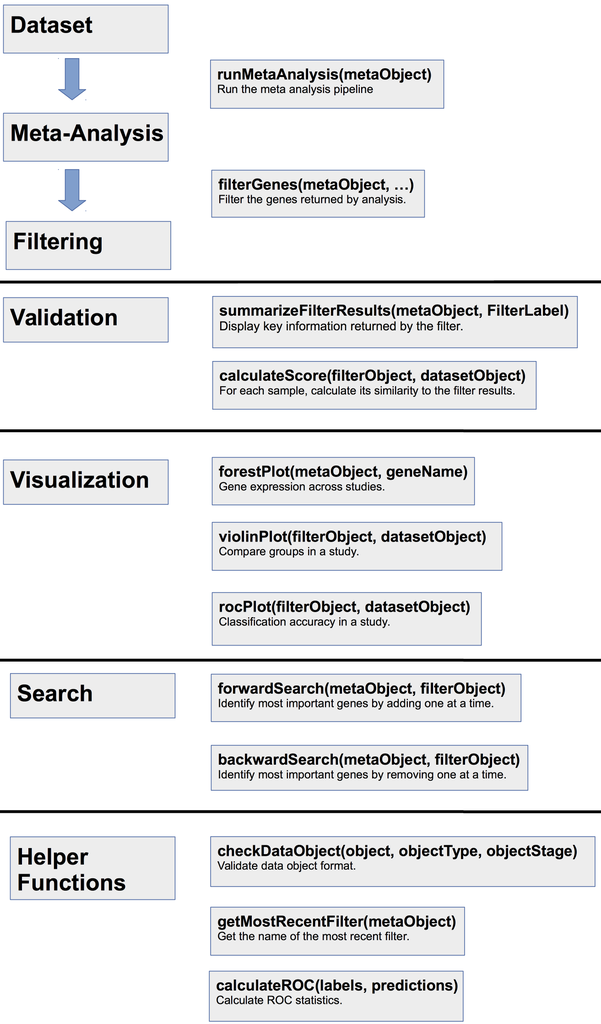

Eq5

## 0.4 Performing a Meta-Analysis using the MetaIntegrator package

### 0.4.1 1. Create a `metaObject` as input for analysis

#### 0.4.1.1 Collect gene expression data

- search gene expression experiments of interest at [GEO](http://www.ncbi.nlm.nih.gov/geo/) or [ArrayExpress](http://www.ncbi.nlm.nih.gov/pubmed/12519949)
- download the DataSet SOFT files for experiments

#### 0.4.1.2 Create a `datasetObject` for each gene expression [GEO dataset](http://www.ncbi.nlm.nih.gov/geo/info/datasets.html)

- unzip and open the DataSet SOFT file
- extract and reformat expression and phenotype information using e.g. a spreadsheet application such as MS Excel
- populate expression (`datasetObject$expr`) and phenotype (`datasetObject$pheno`) information using the `read.table()` function in `R`
- set the `datasetObject$class` vector using the phenotype information (0 is control, 1 is case)
- provide mapping of array probe IDs to gene names for the microarray platform used in the experiment in the `datasetObject$keys` vector. Mappings are usually stored in GPL files (for format details see [GEO Platform guidelines](http://www.ncbi.nlm.nih.gov/geo/info/platform.html)).
- set name of the dataset in `datasetObject$formattedName`

The final `datasetObject` should have the structure:

```
datasetObject: named list
  $class: named vector. Names are sample names. Values are 0 if control, 1 if case.
  $expr: matrix. Row names are probe names. Column names are sample names. Values are expression values
  $keys: named vector. Names are probe names. Values are gene names.
  $pheno: data frame. Row names are the sample names. Column names are the annotation information (none required).
  $formattedName: string. A formatted name for this dataset which will be used in plots.
```

**Example object structure for one `datasetObject` from `tinyMetaObject`:**

```r
dataObj1 <- tinyMetaObject$originalData$PBMC.Study.1
str(dataObj1, max.level = 1)
```

```
## List of 5
##  $ class        : Named num [1:115] 1 1 1 1 1 1 1 1 1 1 ...
##   ..- attr(*, "names")= chr [1:115] "Sample 1" "Sample 2" "Sample 3" "Sample 4" ...
##  $ expr         : num [1:190, 1:115] 10.3 13.6 13.2 13.8 10.2 ...
##   ..- attr(*, "dimnames")=List of 2
##  $ keys         : Named chr [1:190] "Gene41" "Gene58" "Gene112" "Gene59" ...
##   ..- attr(*, "names")= chr [1:190] "1294_at" "200036_s_at" "200080_s_at" "200089_s_at" ...
##  $ pheno        :'data.frame':   115 obs. of  8 variables:
##  $ formattedName: chr "PBMC Study 1"
```

**Note: Gene expression values in `dataObj1$expr` should be in $log_2$ scale and the expression data might need normalization. Also, negative gene expression values are problematic for geometric mean calculation.**

This can be checked by generating a boxplot of the dataset expression values:

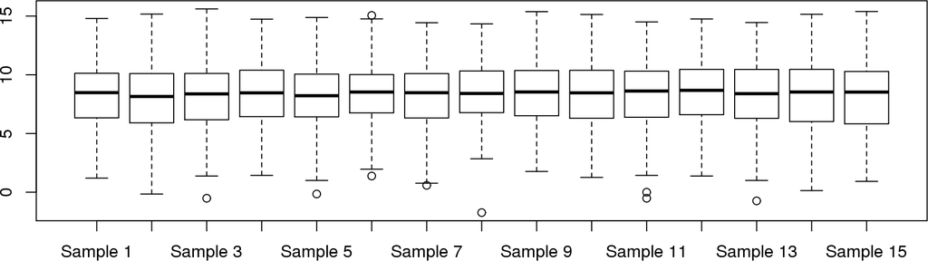

```r
boxplot(dataObj1$expr[,1:15]) # -> shows samples 1-15, to see all run: boxplot(dataObj1$expr)
```

#### 0.4.1.3 Check your `datasetObject` using `checkDataObject()`

The function checks for errors within the `datasetObject`. I returns `TRUE` if the object passed error checking, `FALSE` otherwise, and it prints warning messages explaining failed checks.

```r
checkDataObject(dataObj1, "Dataset")
```

```
## [1] TRUE
```

#### 0.4.1.4 Create `metaObject` from dataset objects

Generate a named list of dataset objects that have been imported for analysis:

```r
# use the additional 2 example datasets from tinyMetaObject
dataObj2 = tinyMetaObject$originalData$Whole.Blood.Study.1
dataObj3 = tinyMetaObject$originalData$Whole.Blood.Study.2
# and create the metaObject
discovery_datasets <- list(dataObj1, dataObj2, dataObj3)
names(discovery_datasets) = c(dataObj1$formattedName, dataObj2$formattedName, dataObj3$formattedName)
exampleMetaObj=list()
exampleMetaObj$originalData <- discovery_datasets
```

**IMPORTANT: Keep at least one dataset out of the discovery datasets to use it for validation!**

The final `metaObject` should have the structure:

```
metaObject: named list
  $originalData: named list [1]
      $datasetName: Dataset object. 'datasetName' will be the (unquoted) name of that dataset.[0,n]
```

#### 0.4.1.5 Optional: Check your `metaObject` before MetaAnalysis using `checkDataObject()`

The function checks for errors within the `metaObject`.

**Example how to check your `metaObject`:**

```r
checkDataObject(exampleMetaObj, "Meta", "Pre-Analysis")
```

```
## [1] TRUE
```

### 0.4.2 2. Run Meta-Analysis on discovery cohorts

#### 0.4.2.1 Run Meta-Analysis with `runMetaAnalysis()`

Once the data is written to `metaObject$originalData`, the Meta-Analysis can be started by:

```
runMetaAnalysis(metaObject)
```

The Meta-Analysis results are written into `metaObject$metaAnalysis` and the results of the leave-one-out analysis into `metaObject$leaveOneOutAnalysis` For details see Meta-Analysis algorithm above

**Example:**

```r
exampleMetaObj <- runMetaAnalysis(exampleMetaObj, maxCores=1)
```

```
## Found common probes in 3
## Computing effect sizes...
## Computing summary effect sizes...
## Computing Fisher's output...
```

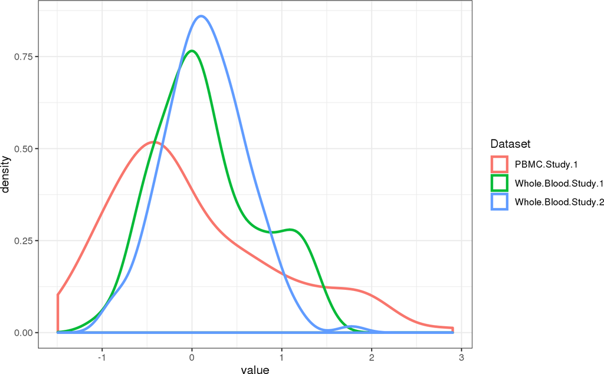

```
## Computing effect sizes...
## Computing summary effect sizes...
## Computing Fisher's output...Found common probes in 2
## Computing effect sizes...
## Computing summary effect sizes...
## Computing Fisher's output...Computing effect sizes...
## Computing summary effect sizes...
## Computing Fisher's output...
```

The generated effect size plot compares the effect size distributions of the datasets used in the Meta-Analysis. Ideally, the effect sizes should have a normal distribution around 0.

**Check if the result has been written into `$metaAnalysis` and `$leaveOneOutAnalysis`:**

```r
str(exampleMetaObj, max.level = 2)
```

```
## List of 3
##  $ originalData       :List of 3
##   ..$ PBMC.Study.1       :List of 5
##   ..$ Whole.Blood.Study.1:List of 5
##   ..$ Whole.Blood.Study.2:List of 5
##  $ metaAnalysis       :List of 4
##   ..$ datasetEffectSizes             : num [1:167, 1:3] 0.959 0.279 -0.192 -0.332 -0.242 ...
##   .. ..- attr(*, "dimnames")=List of 2
##   ..$ datasetEffectSizeStandardErrors: num [1:167, 1:3] 0.312 0.306 0.305 0.306 0.305 ...
##   .. ..- attr(*, "dimnames")=List of 2
##   ..$ pooledResults                  :'data.frame':  167 obs. of  14 variables:
##   ..$ analysisDescription            : chr "MetaAnalysis: Random Effects Model"
##  $ leaveOneOutAnalysis:List of 3
##   ..$ removed_PBMC.Study.1       :List of 4
##   ..$ removed_Whole.Blood.Study.1:List of 4
##   ..$ removed_Whole.Blood.Study.2:List of 4
```

#### 0.4.2.2 Filter out significant genes from meta-analysis results with `filterGenes()`

**After the Meta-Analysis results have been written to the `metaObject`, they can be examined using different gene filter criteria with `filterGenes()`. The standard filterParameter are the FDR cutoff and leave-one-out analysis on/off:**

`FDRThresh`: FDR cutoff: a gene is selected, if it has a p-value less than or equal to the FDR cutoff (default: `0.05`)

`isLeaveOneOut`: Do leave-one-out analysis on discovery datasets (default: `TRUE`). Needs at least 2 datasets for discovery.  
(Detailed optional parameter see: `filterGenes()`)

**Example:**

```r
exampleMetaObj <- filterGenes(exampleMetaObj, isLeaveOneOut = TRUE, FDRThresh = 0.001)
```

### 0.4.3 3. Validation on independent validation cohorts

#### 0.4.3.1 Summarize filtered meta-analysis results with `summarizeFilterResults()`

Either use the filter label as input for `summarizeFilterResults()`

```r
summarizeFilterResults(exampleMetaObj, "FDR0.001_es0_nStudies1_looaTRUE_hetero0")
```

Or use the most recent filter with the function `getMostRecentFilter()`

```r
summarizeFilterResults(exampleMetaObj, getMostRecentFilter(exampleMetaObj))
```

```
## $pos
##        effectSize effectSizeStandardError effectSizePval effectSizeFDR
## Gene27   1.163213               0.1066813   1.107537e-27  1.849586e-25
## Gene13   1.629049               0.1514056   5.345649e-27  4.463617e-25
## Gene36   1.185257               0.1600311   1.297580e-13  3.095656e-12
## Gene26   1.009014               0.1396065   4.917610e-13  1.026551e-11
## Gene17   1.186679               0.1739487   8.978005e-12  1.363024e-10
## Gene24   1.056540               0.1798291   4.222159e-09  4.406879e-08
##        tauSquared numStudies cochranesQ heterogeneityPval fisherStatUp
## Gene27 0.00000000          3 0.01310449         0.9934692    130.50116
## Gene13 0.00000000          3 1.39880786         0.4968814    136.99524
## Gene36 0.00000000          2 0.10687482         0.7437306     66.32116
## Gene26 0.00000000          3 1.43300798         0.4884569     68.53009
## Gene17 0.04541667          3 3.95629827         0.1383250     83.64513
## Gene24 0.01187769          2 1.16373481         0.2806923     55.75905
##        fisherPvalUp  fisherFDRUp fisherStatDown fisherPvalDown fisherFDRDown
## Gene27 1.008046e-25 8.417186e-24   1.818131e-02      0.9999999             1
## Gene13 4.313804e-27 7.204053e-25   4.881354e-05      1.0000000             1
## Gene36 1.355405e-13 1.886272e-12   9.336704e-05      1.0000000             1
## Gene26 8.182527e-13 9.760586e-12   6.352420e-03      1.0000000             1
## Gene17 6.298572e-16 2.103723e-14   1.365882e-04      1.0000000             1
## Gene24 2.252504e-11 2.285523e-10   3.895598e-05      1.0000000             1
##
## $neg
##        effectSize effectSizeStandardError effectSizePval effectSizeFDR
## Gene59 -0.5772361              0.08198619   1.913453e-12  3.550518e-11
## Gene54 -0.4100211              0.08539501   1.575098e-06  8.768044e-06
##         tauSquared numStudies cochranesQ heterogeneityPval fisherStatUp
## Gene59 0.001354013          3   2.119463         0.3465489    0.4061699
## Gene54 0.004890694          3   2.407518         0.3000641    6.2240635
##        fisherPvalUp fisherFDRUp fisherStatDown fisherPvalDown fisherFDRDown
## Gene59    0.9988003   1.0000000       42.66136   1.360968e-07  1.623441e-06
## Gene54    0.3985643   0.6656024       68.13827   9.843187e-13  5.479374e-11
```

#### 0.4.3.2 Generate a violin plot for a validation `datasetObject` with `violinPlot()`

A violin plot is similar to a box plot, except the width of each violin is proportional to the density of points. It can be used to validate how well the selected gene set can be used to separate the groups (e.g. cases vs. controls). P-values are calculated and displayed on the plots.

**Example:**

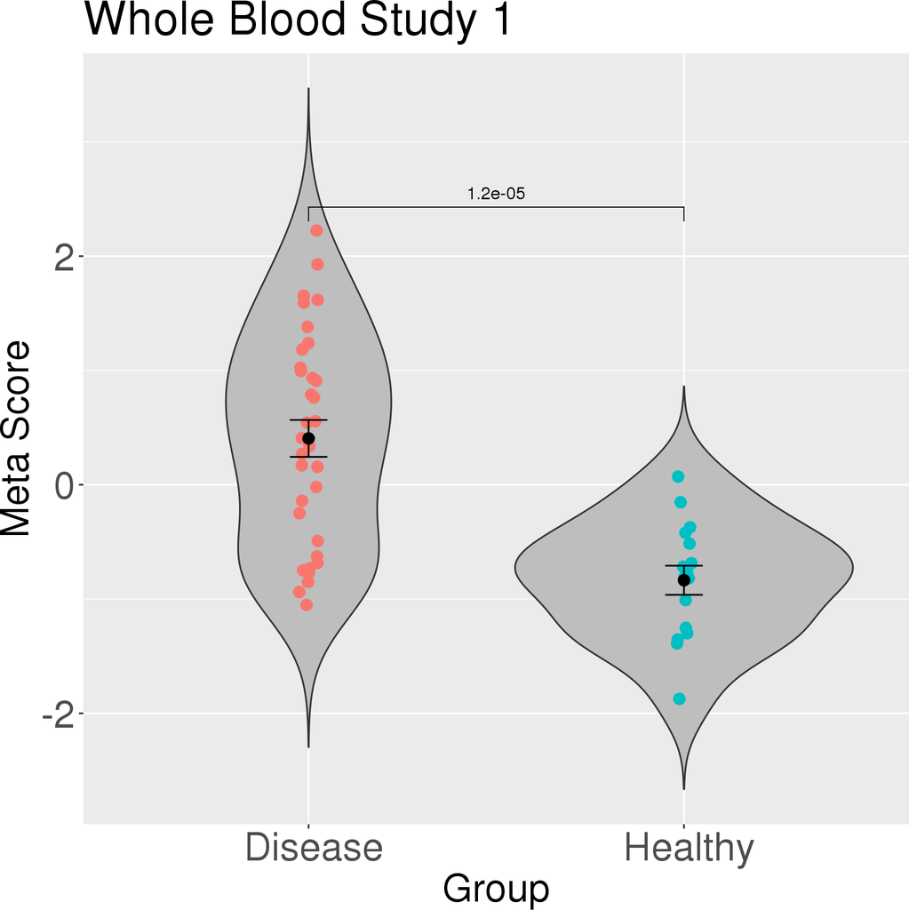

```r
violinPlot(exampleMetaObj$filterResults$FDR0.001_es0_nStudies1_looaTRUE_hetero0, dataObj2, labelColumn = 'group')
```

**Note: usually the validation would be performed on an independent validation dataset not like here on the discovery `dataObj2`!**

#### 0.4.3.3 Generate a ROC plot for a validation `datasetObject` with `rocPlot()`

In addition, a ROC plot can be generated to validate how well the groups (e.g. cases vs. controls) can be separated with the selected gene set. The function `rocPlot()` returns a standard ROC plot, with area under the curve (AUC) and 95% confidence interval (CI) calculated according to Hanley method [(Hanley et al, 1982)](http://www.ncbi.nlm.nih.gov/pubmed/7063747).

**Example:**

```
## Used  6 of  6  pos genes, and  2  of  2  neg genes
## For dataset Whole Blood Study 1, AUC = 0.866
```

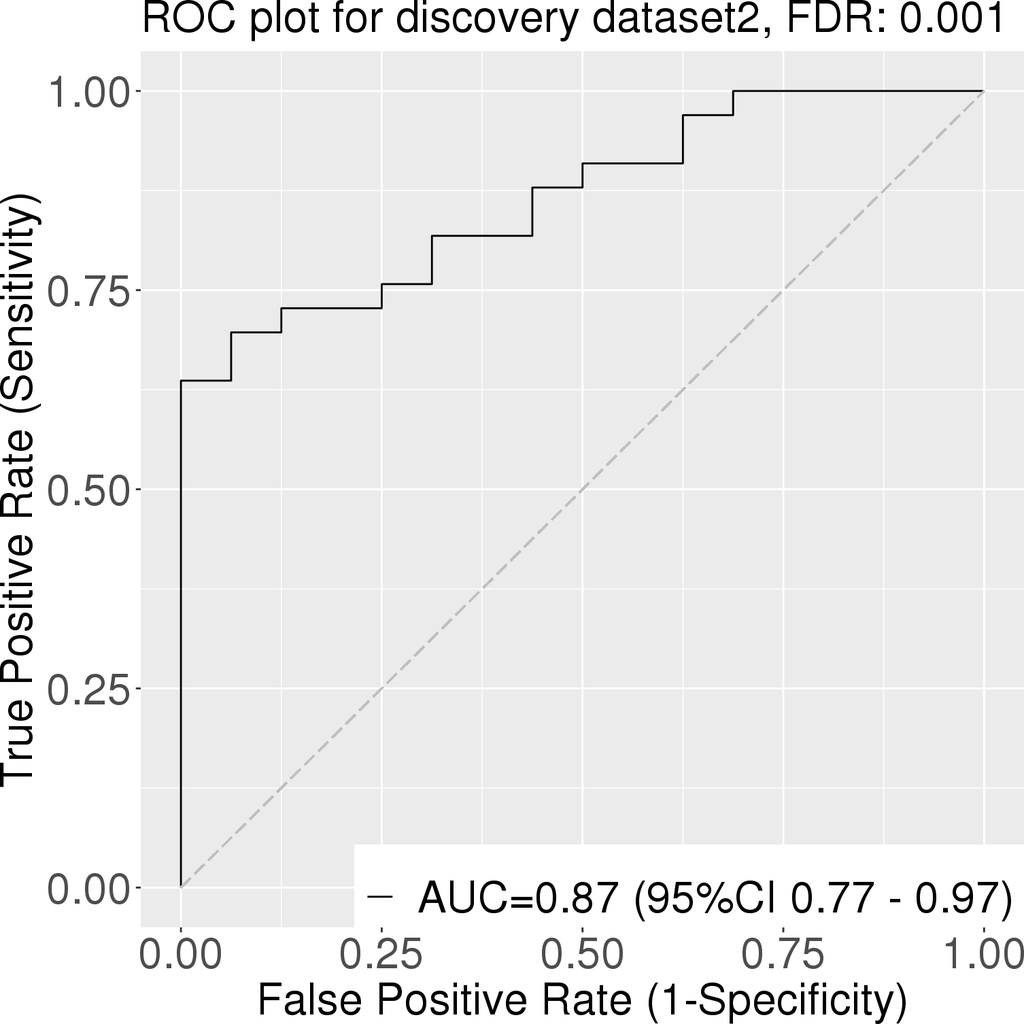

```r
rocPlot(exampleMetaObj$filterResults$FDR0.001_es0_nStudies1_looaTRUE_hetero0, dataObj2, title = "ROC plot for discovery dataset2, FDR: 0.001")
```

**Note: Usually the validation would be performed on an independent validation dataset not like here on the discovery `dataObj2`!**

#### 0.4.3.4 Generate forest plot for gene of interest with `forestPlot()`

A forest plot can be used to compare the expression values of a gene across different datasets. The size of the blue boxes is proportional to the number of samples in the study and light blue lines indicate the standard error of the effect sizes for each study (95% confidence interval). The summary effect size for all studies is indicated as yellow diamond below and the width of the diamond indicates the summary standard error.

**Example:**

```
## [1] "character"
```

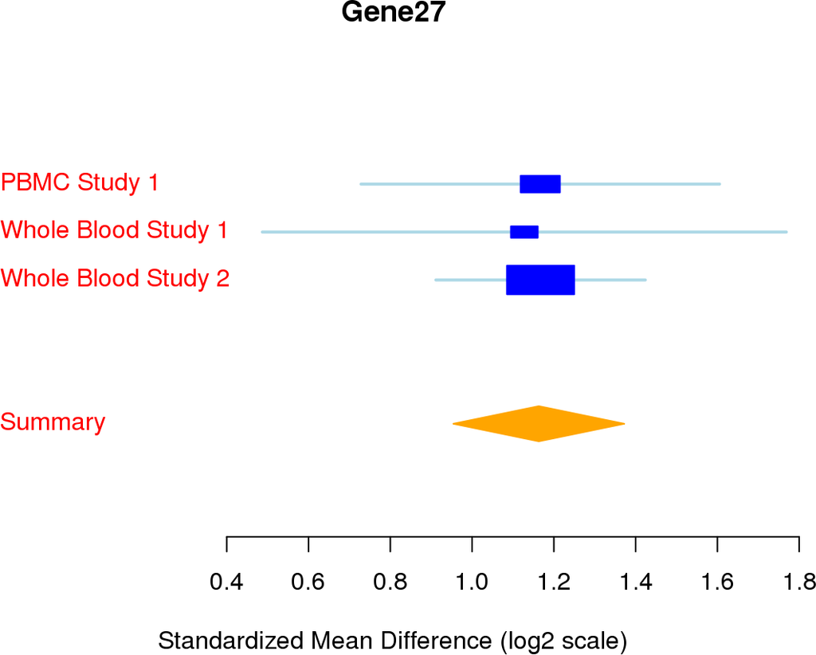

```r
forestPlot(exampleMetaObj, "Gene27")
```

#### 0.4.3.5 Optional: Calculate signature score for gene sets with `calculateScore()`

Given a gene set of interest, it is often desirable to summarize the expression of that gene set using a single integrated signature score (for details see above). The method `calculateScore()` calculates the geometric mean of the expression level of all positive genes, minus the geometric mean of the expression level of all negative genes. Although mostly used internally (e.g. to calculate the Z-scores for `violinPlot()`), the function has been exported in case users want to compare multiple classes, etc., using the same Z-score as is used for producing two-class comparisons.

**Example:**

```r
calculateScore(exampleMetaObj$filterResults$FDR0.001_es0_nStudies1_looaTRUE_hetero0, dataObj2)
```

```
## Used  6 of  6  pos genes, and  2  of  2  neg genes
```

```
##  [1] -0.15306434 -0.68681735 -0.81023751 -0.81863726 -1.25195646 -1.87385218
##  [7] -1.35369218 -1.00883527 -1.29960805 -1.38863102 -0.76999804 -0.71777841
## [13]  0.07056772 -0.37165758 -0.42032379 -0.51503945 -0.74899507 -0.14092856
## [19]  2.22416036 -0.01965896  0.78892927  0.40788351  0.17038795  1.59325560
## [25]  0.15670475  0.76272870 -0.85048217  0.55503900 -0.73279309 -0.77016199
## [31] -0.49176551  0.54325166  0.93394146  0.26956889  1.61741129  1.23905868
## [37]  0.99592740  1.38078543  1.02264230  0.90994709  0.33786849 -0.24990791
## [43] -1.05145613 -0.93880708  1.92819891  1.18440716 -0.62728134 -0.68417686
## [49]  1.65387796
```

Typically, this vector would be added as `$score` column in `datasetObject$pheno`.

## 0.5 Overview objects and functions

### 0.5.1 MetaIntegrator objects

#### 0.5.1.1 `metaObject`

The `metaObject` contains all input and output data of the Meta-Analysis

```
metaObject: named list
  $originalData: named list [1]
       $datasetName: datasetObject. 'datasetName' will be the (unquoted) name of that dataset.[0,n]
  $metaAnalysis: MetaAnalysisObject. Corresponds to the meta-analysis results including all data in originalData [0,1]
  $leaveOneOutAnalysis: named list [0,1]
       $removed_datasetName: MetaAnalysisObject. 'datasetName' will be name of removed dataset in LOOA. [0,n]
  $filterResults: named list [0,1]
       $filterCriteria: filterObject. 'filterCriteria' will be a string representation of the filter criteria. [0,n]
```

#### 0.5.1.2 `datasetObject`

The `datasetObject` contains all information of one GEO gene expression dataset

```
datasetObject: named list
  $class: named vector. Names are sample names. Values are 0 if control, 1 if case.
  $expr: matrix. Row names are probe names. Column names are sample names. Values are expression values
  $keys: named vector. Names are probe names. Values are gene names.
  $pheno: data frame. Row names are the sample names. Column names are the annotation information (none required).
  $formattedName: string. A formatted name for this dataset which will be used in plots.
```

#### 0.5.1.3 `MetaAnalysisObject`

Object that contains results of one Meta-Analysis generated by `runMetaAnalysis()` and stored in `metaObject$metaAnalysis` and `metaObject$leaveOneOutAnalysis`

```
MetaAnalysisObject: named list
  $datasetEffectSizes: data frame. Column names are dataset names. Row names are gene names. Values are dataset-specific effect sizes.
  $datasetEffectSizeStandardErrors: data frame. Column names are dataset names. Row names are gene names. Values are dataset-specific effect size standard errors.
  $pooledResults: data frame. Row names are gene names. Column names are:
      $effectSize: double. pooled.ES$summary
      $effectSizeStandardError: double. Non-negative.
      $effectSizePval: double. Ranges from 0 to 1.
      $effectSizeFDR: double. Ranges from 0 to 1.
      $tauSquared: double. Non-negative.
      $numStudies: integer. Non-negative.
      $cochranesQ: double. Non-negative.
      $heterogeneityPval: double. Ranges from 0 to 1.
      $fisherStatUp: double. Non-negative.
      $fisherPvalUp: double. Ranges from 0 to 1.
      $fisherFDRUp: double. Ranges from 0 to 1.
      $fisherStatDown: double. Non-negative.
      $fisherPvalDown: double. Ranges from 0 to 1.
      $fisherFDRDown: double. Ranges from 0 to 1.
  $analysisDescription: string. Describes details of meta-analysis applied.
```

#### 0.5.1.4 `filterObject`

Object that contains filter results of one Meta-Analysis generated by `filterGenes()` and stored in `metaObject$filterResults`

```
filterObject: named list
  $posGeneNames: character vector. Values are positively-regulated gene names which passed the filter.
  $negGeneNames: character vector. Values are negatively-regulated gene names which passed the filter.
  $FDRThresh: double. Ranges from 0 to 1.
  $effectSizeThresh: double. Non-negative.
  $numberStudiesThresh: integer. Non-negative.
  $isLeaveOneOut: boolean.
  $heterogeneityPvalThresh: double. Ranges from 0 to 1.
  $filterDescription: string. Describes and additional details of the filter.
  $timestamp: POSIXct. Result from Sys.time() call from when the filter was executed.
```

### 0.5.2 Meta-Analysis functions

#### 0.5.2.1 `runMetaAnalysis()`

Given a `metaObject` with `$originalData` populated this function will run the meta-analysis algorithm. It returns a modified version of the `metaObject` with the meta-analysis results written into `metaObject$metaAnalysis` and the results of the leave-one-out analysis into `metaObject$leaveOneOutAnalysis`.

**Usage:**

```r
metaObject <- runMetaAnalysis(metaObject)
```

**Args:**

`metaObject`: a `metaObject` which must have the `$originalData`  
**Generates:**

Effect size plots  
**Returns:**

A modified version of the `metaObject` with both, `$metaAnalysis` and `$leaveOneOutAnalysis`, populated with a `MetaAnalysisObject`

#### 0.5.2.2 `filterGenes()`

After the meta-analysis results have been written to the `metaObject`, the results can be examined using different gene filtering criteria. This function will use the given filter parameter to select genes that fulfill the filter conditions. The function returns a modified version of the metaObject with results stored in `metaObject$filterResults`

**Usage:**

```r
metaObject <- filterGenes(metaObject, filterParameter)
```

**Args:**

`metaObject`: a metaObject, which must have the `$originalData`, `$metaAnalysis` populated optional filterParameter:

`isLeaveOneOut`: Do leave-one-out analysis on discovery datasets (Default: TRUE). Needs at least 2 datasets for discovery.

`FDRThresh`: FDR cutoff: a gene is selected, if it has a p-value less than or equal to the FDR cutoff (Default: 0.05)

`effectSizeThresh`: a gene is selected, if the absolute value of its effect size is above this threshold (default: 0)

`numberStudiesThresh`: number of studies in which a selected gene has to be significantly up/down regulated (Default: 1)

`heterogeneityPvalThresh`: heterogeneity p-value cutoff (filter is off by default: `heterogeneityPvalThresh = 0`). Genes with significant heterogeneity and, thus a significant (low) heterogeneity p-value, can be filtered out by using e.g.: `heterogeneityPvalThresh = 0.05` (removes all genes with heterogeneity p-value < 0.05)  
**Returns:**

`metaObject`: A modified version of the input `metaObject` with an additional `filterObject` stored within `metaObject$filterResults`